# scSHC Demo on Real Data

Isabella N. Grabski

Department of Biostatistics, Harvard University

isabellagrabski@g.harvard.edu

15 April 2023

#### Package

scSHC 0.1.0

# 1 Introduction

We introduce a significance analysis approach to clustering single-cell RNA-sequencing (scRNA-seq) data. Our approach is implemented in two ways. First, we present a stand-alone clustering pipeline, called single-cell significance of hierarchical clustering (sc-SHC), that builds hypothesis testing into a hierarchical clustering framework. Second, we offer a way to apply significance analysis to any set of pre-computed clusters.

In this demo, we show how our approach can be applied to some real datasets.

# 2 Single-Cell Significance of Hierarchical Clustering

First, we load in the `ZhaoImmuneLiver` data from the package `scRNAseq`. We extract the raw UMI counts from these data, and for simplicity, we restrict our attention to the liver cells from Donor 2, which has the largest number of liver cells.

```r
set.seed(41423)

library(scSHC)
library(scRNAseq)

liver <- ZhaoImmuneLiverData()
liver <- liver[,liver$sample=='donor 2 liver']
liver.cnts <- counts(liver)
```

```r
clusters <- scSHC(liver.cnts)
table(clusters[[1]],liver$broad)
```

```
##
##      ASC    B   Mo  NKT
##   1    0 3260    1    2
##   2  530    0    0    0
##   3 2580    7    4    7
##   4   65   66   23 3544
##   5    2    0  239    0
##   6    0    0  447    4
```

Our approach finds six clusters. When compared to the broad cell type labels, we see one corresponds to B cells; one corresponds to NKT cells; two correspond to ASC cells; and the last two correspond to monocytes. We can also view the dendrogram of clusters that were tested and print out their adjusted p-values.

```r
clusters[[2]]
```

```
##                       levelName
## 1  Node 0: 0
## 2   ¦--Node 1: 0
## 3   ¦   ¦--Cluster 1: 1
## 4   ¦   °--Node 3: 0
## 5   ¦       ¦--Node 4: 0
## 6   ¦       ¦   ¦--Cluster 5: 1
## 7   ¦       ¦   °--Cluster 6: 1
## 8   ¦       °--Cluster 4: 0.8
## 9   °--Node 2: 0
## 10      ¦--Cluster 2: 1
## 11      °--Cluster 3: 1
```

# 3 Significance Analysis on Pre-Computed Clusters

We now demonstrate our significance analysis approach applied on pre-computed clusters. These clusters can arise from any clustering algorithm, including when manual changes were made to the output. Here, we show results when applying our approach to the 25 clusters that had been originally found in these data, again using the default FWER of 0.05. This takes about 7.5 minutes with two cores.

```r
new <- testClusters(liver.cnts,cluster_ids=liver$Cluster)
table(new[[1]],liver$Cluster)
```

[output not shown]

```r
table(new[[1]],liver$broad)
```

```
##
##         ASC    B   Mo  NKT
##   new1 3056    0    0    0
##   new2  121    0  714   90
##   new3    0    0    0 2221
##   new4    0 3333    0    0
##   new5    0    0    0 1246
```

Our approach merged the 25 clusters into five, which are similar but not exactly the same as the six clusters we had found in our de novo approach. This is to be expected, since the clustering is now based on assessing the provided labels, which can differ in how they partition cells from our de novo clustering pipeline. Here, we see that we have one cluster corresponding to B cells; one cluster corresponding to ASC cells; one cluster corresponding to monocytes; and two clusters corresponding to NKT cells. We can again view the adjusted p-values for each split:

```r
new[[2]]
```

```
##                      levelName
## 1 Node 0: 0
## 2  ¦--Cluster 1: 0.2
## 3  °--Node 1: 0
## 4      ¦--Node 2: 0
## 5      ¦   ¦--Cluster 3: 1
## 6      ¦   °--Node 3: 0
## 7      ¦       ¦--Cluster 4: 1
## 8      ¦       °--Cluster 5: 1
## 9      °--Cluster 2: 0.45
```

Finally, we visualize all 3 clustering results.

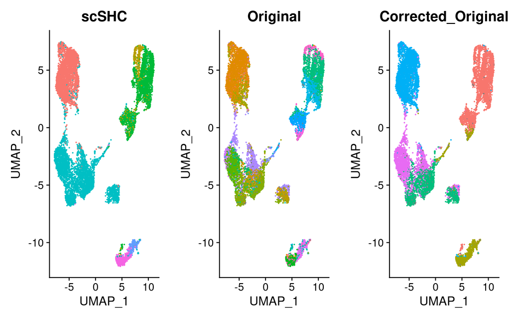

# 4 Batch Effects

In many settings, we may have batch effects due to multiple samples or other factors. These can be input into `scSHC()` or `testClusters()` as a character vector in the same order as the cells in the data. As an example, let’s now consider the `KotliarovPBMCData` from the `scRNAseq` package, which has samples coming from two batches.

```r
set.seed(41423)

kot <- KotliarovPBMCData()
kot.cnts <- counts(kot)

clusters <- scSHC(kot.cnts,batch=kot$batch)
table(clusters[[1]],kot$batch)
```

```
##
##        1    2
##   1 4926 4434
##   2 2116 2899
##   3 3448 2508
##   4 2141 2336
##   5 2915 2493
##   6 8638 7905
##   7 2192 1744
##   8 4292 3667
```

On this 58,000-cell dataset, our clustering pipeline takes 24 minutes to run. We see a total of 8 clusters, with good mixing across the two batches. We can again view the adjusted p-values:

```r
clusters[[2]]
```

```
##                              levelName
## 1  Node 0: 0
## 2   ¦--Cluster 1: 1
## 3   °--Node 1: 0
## 4       ¦--Node 2: 0
## 5       ¦   ¦--Cluster 2: 1
## 6       ¦   °--Node 4: 0
## 7       ¦       ¦--Cluster 4: 1
## 8       ¦       °--Node 6: 0
## 9       ¦           ¦--Cluster 7: 1
## 10      ¦           °--Cluster 8: 0.34
## 11      °--Node 3: 0
## 12          ¦--Cluster 3: 1
## 13          °--Node 5: 0
## 14              ¦--Cluster 5: 1
## 15              °--Cluster 6: 1
```

```r
data.seurat <- CreateSeuratObject(counts=kot.cnts)
data.seurat <- NormalizeData(data.seurat)
data.seurat <- FindVariableFeatures(data.seurat)
data.seurat <- ScaleData(data.seurat)
data.seurat <- RunPCA(data.seurat)
data.seurat <- RunUMAP(data.seurat,dims=1:30)
data.seurat <- FindNeighbors(data.seurat)
data.seurat <- FindClusters(data.seurat)
```

```
## Modularity Optimizer version 1.3.0 by Ludo Waltman and Nees Jan van Eck
##
## Number of nodes: 58654
## Number of edges: 1684956
##
## Running Louvain algorithm...
## Maximum modularity in 10 random starts: 0.8824
## Number of communities: 17
## Elapsed time: 16 seconds
```

```r
new <- testClusters(kot.cnts,batch=kot$batch,cluster_ids=Idents(data.seurat))
table(new[[1]],Idents(data.seurat))
```

```
##
##            0     1     2     3     4     5     6     7     8     9    10    11
##   new1     0     0     0     0     0     0     0     0     0     0     0     0
##   new2     0     0     0     0     0     0  4489     0     0     0     0     0
##   new3     0     0     0     0  5054     0     0     0     0  1884  1626   925
##   new4     0     0     0  5979     0     0     0     0     0     0     0     0
##   new5 10059  8228  6022     0     0     0     0     0     0     0     0     0
##   new6     0     0     0     0     0     0     0  4370     0     0     0     0
##   new7     0     0     0     0     0  4941     0     0  3939     0     0     0
##
##           12    13    14    15    16
##   new1     0     0   191     0     0
##   new2     0     0     0     0     0
##   new3   474     0     0    91     0
##   new4     0   315     0     0    67
##   new5     0     0     0     0     0
##   new6     0     0     0     0     0
##   new7     0     0     0     0     0
```

```r
new[[2]]
```

```
##                              levelName
## 1  Node 0: 0
## 2   ¦--Node 1: 0
## 3   ¦   ¦--Cluster 1
## 4   ¦   °--Cluster 2
## 5   °--Node 2: 0
## 6       ¦--Cluster 3: 1
## 7       °--Node 3: 0
## 8           ¦--Cluster 4: 1
## 9           °--Node 4: 0
## 10              ¦--Cluster 5: 1
## 11              °--Node 5: 0
## 12                  ¦--Cluster 6
## 13                  °--Cluster 7: 0.54
```

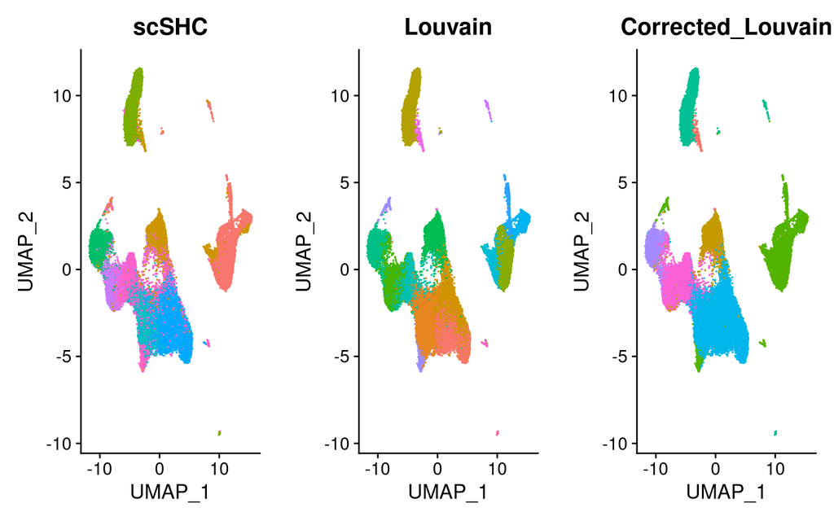